# Mais qui a des téléphones ?!

Justine Blanchot et Elyass Sayd, Groupe 0

25/04/2022

### Introduction

Avant la fameuse conférence *Apple Keynote* de 2007 par Steve Jobs où il annonçait la sortie du premier iPhone, personne n’aurait pu imaginer que les écrans tactiles se retrouveraient dans toutes les mains. L’iPhone était le précurseur du marché des smartphones, marché qui a connu une des expansions les plus fulgurantes du XXe siècle, avec l’amélioration constante des infrastructures internet. Aurions-nous pu prévoir quels marchés allaient-être les plus réceptifs à l’arrivée de cette technologie? À l’aide de quels critères? Nous allons au fil de ce rapport nous questionner sur les corrélations possibles pour un pays donné entre le nombre de téléphones pour mille habitants et différents critères classiques pour mesurer le développement d’un pays.

### Problématique et objectif

A partir d’un jeu de données issu de Kaggle, publié en 2017 par Fernando Lasso, intitulé “Countries of the world” et rassemblant des données du gouvernement américain (anciennes données du CIA World Factbook et International Consortium for the Advancement of Academic Publication https://gsociology.icaap.org/dataupload.html), nous allons essayer d’expliquer l’engouement autour du téléphone mobile en 2000 en fonction de certains indicateurs.

Nous tenterons donc de répondre à la problématique suivante:

**Aurions-nous pu anticiper la réussite du marché des téléphones portables dans un pays à l’aide des indicateurs classiques de développement? Si oui, à l’aide desquels?**

#### Sommaire:

I - Analyse descriptive des données

A - Analyse du jeu de données

B - Analyse univariée de la variable d’intérêt

C - Analyse bi-variée

II - Régression linéaire multiple

A - Introduction

B - Sélection de variable

C - Validation du modèle

III - Modélisation linéaire avec variable qualitative, réalisation d’une ANOVA.

A - Apprentissage du modèle

B - Test du modèle

### I - Analyse descriptive des données

#### A - Analyse du jeu de données

Le jeu de données que nous avons choisi contient les données de 227 pays par rapport à 19 variables. Dans le cadre de cette étude, nous nous limiterons aux variables suivantes: la région d’appartenance du pays, la densité de population (nombre d’habitants par miles carré), le PIB par habitant, le taux de natalité et, enfin, la part de la population active travaillant dans l’agriculture, l’industrie et les services. Parmi ces sept variables, nous avons six quantitatives et une qualitative (la région d’appartenance).

Par définition, les variables Service, Industrie et Agriculture forment une partition de la population active dans le pays.Nous décidons alors de retirer de notre étude, sans perte de précision, la variable Industrie.

#### B - Analyse univariée de la variable d’intérêt

Introduisons des notations:

$T$, pour “téléphones”, est la variables à expliquer, c’est-à-dire le nombres de téléphones pour mille habitants. Dans cette première partie, nous allons analyser les données de $T$.

Commençons par regarder quelques caractéristiques de $T$:

```
   Min. 1st Qu.  Median    Mean 3rd Qu.    Max.
    0.2    32.4   145.9   222.3   364.7   898.0
```

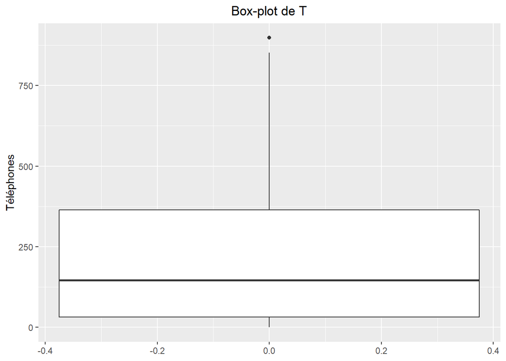

Par lecture de notre sommaire et de notre box-plot, on obtient que la loi n’est pas symétrique, puisque la moyenne, 222.2533654 est différente de la médiane,145.9.

Les deux indicateurs de tendance centrales sont assez bas. Le premier quartile est à 32.4 mais surtout le troisième quartile est égal à 364.7. Cela signifie que 75% des pays ont moins de 364.7 téléphones pour mille habitants.

L’étendue est de 897.8. Cet indicateur est sensible aux valeurs aberrantes et nous voyons dans notre box-plot que nous en avons une. De plus, la longueur d’une des moustaches est assez élevée. L’écart-interquartile est de 332.3. Ainsi, la moitié des pays ont entre 32.4 et 364.7 téléphones pour mille habitants.

L’observation hors-norme est due aux United States soit les États-Unis. Ce n’est pas suprenant que ce soit le pays qui ait le plus de téléphones pour mille habitants, au vue de leur histoire avec les technologies. Nous voyons sur le box-plot qu’il n’est pas tant éloigné de la fin de la moustache.

Avant toutes recherches plus précises sur notre variable $T$, nous allons nous convaincre qu’elle est continue. Pour ce faire, traçons sa fonction de répartition empirique.

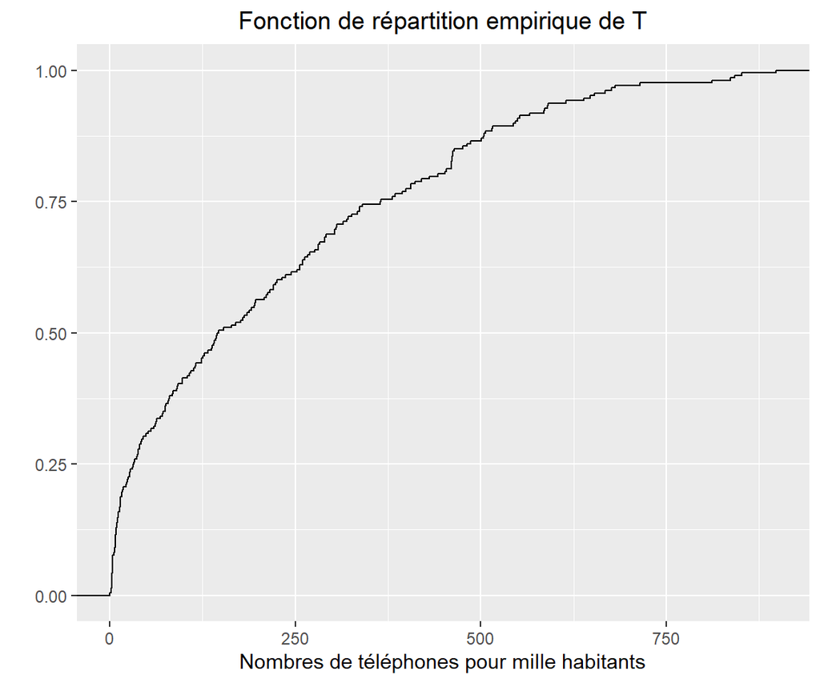

La fonction de répartition empirique de $T$ réalise 200 sauts, ce qui est suffisamment “grand” devant 208 donc notre variable d’intérêt est continue.

Nous pouvons alors tracer son histogramme.

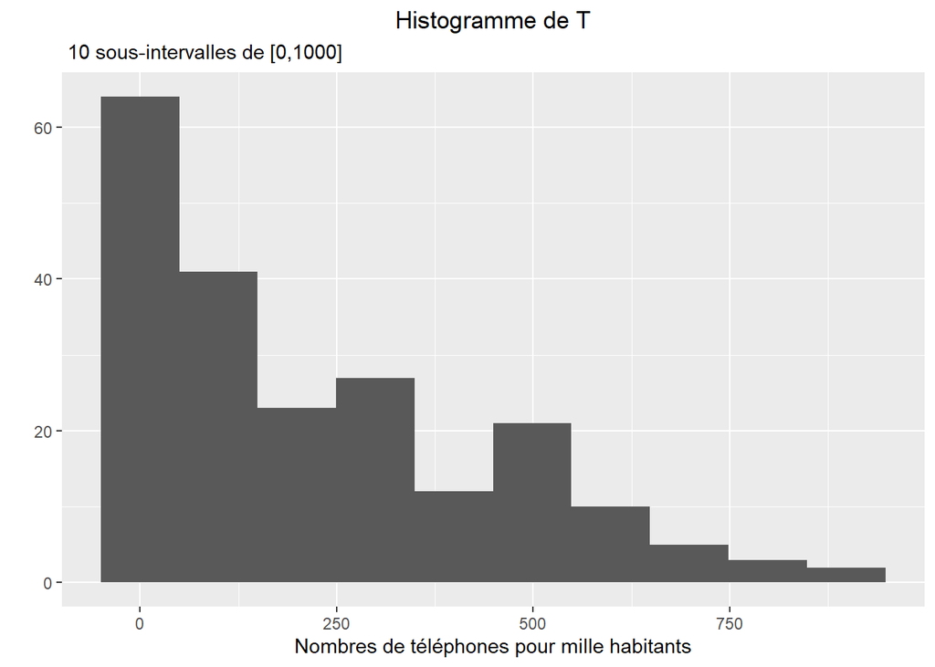

L’histogramme est uni-modal avec un pic en 0, puis à tendance décroissante. On en déduit que dans notre jeu de données, beaucoup de pays ont moins de 100 téléphones pour mille habitants et à l’inverse, peu de pays ont plus de de 700 téléphones pour mille habitants.

Au vu de cet histogramme, nous pouvons penser que $T$ est un échantillon de loi exponentielle, c’est-à-dire que $T$ est la réalisation d’une variable aléatoire $X$ suivant une loi exponentielle de paramètre $\lambda$. L’espérance d’une loi exponentielle est $\frac{1}{\lambda}$. La méthode des moments nous propose la moyenne empirique de $T$ comme estimateur sans biais, consistant et asymptotiquement normal de l’espérance.

La moyenne empirique de $T$ est $\mu =$ 222.2533654. En prenant $\hat \lambda =$ 0.0044994, nous voulons vérifier que notre hypothèse est acceptable. Nous allons alors tracer le QQ-plot entre les quantiles théoriques de $X$ et les quantiles empiriques de $T$.

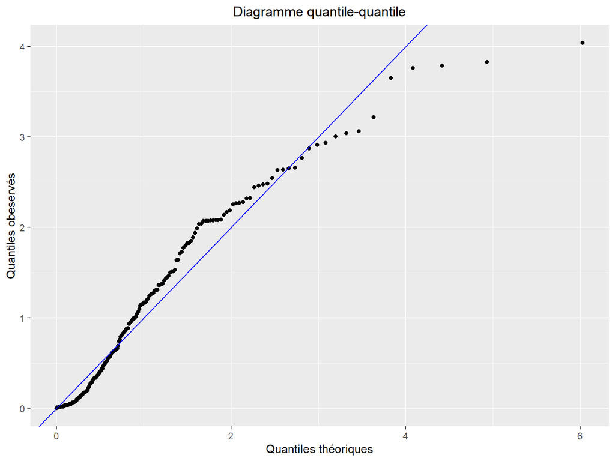

Les points de notre QQ-plot s’alignent bien sur la première bissectrice. C’est encourageant. L’adéquation n’est pas parfaite mais elle est suffisamment raisonnable pour retenir l’hypothèse que $T$ suit une loi exponentielle de paramètre $\hat \lambda$.

Nous allons finaliser notre analyse univariée en réalisant un test de Kolmogorov-Smirnov sur notre échantillon, puisque la variable Téléphones et la loi exponentielle sont toutes deux de lois continues.

```
    Two-sample Kolmogorov-Smirnov test

data:  df.countries$Téléphones and rexpsample
D = 0.93269, p-value < 2.2e-16
alternative hypothesis: two-sided
```

Notre p-valeur est inférieure à 2.2e-16 donc on rejette $H_0$ au profit de l’hypothèse alternative $H_1$ sans hésitation. On peut conclure que notre variable $T$ ne suit pas une loi exponentielle de paramètre $\hat\lambda$. $T$ est la réalisation d’une autre loi, dont on ne connait pas la nature exacte.

Nous avons ainsi terminé cette partie d’analyse univariée.

#### C - Analyse bi-variée

Nous allons maintenant nous intéresser aux potentielles corrélations entre notre variable d’intérêt $T$ et les autres variables de notre jeu de données.

Commençons par calculer la matrice de corrélation et présentons un diagramme de dispersion de toutes les paires de variables, pour chaque variable quantitative de notre jeu de données.

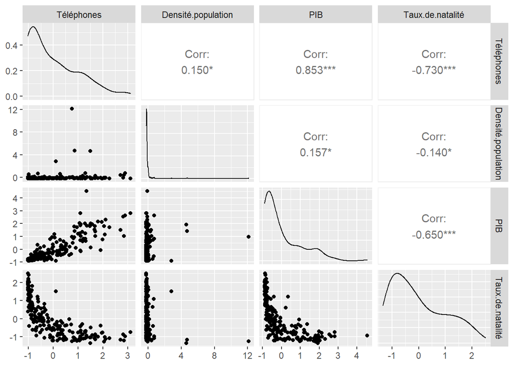

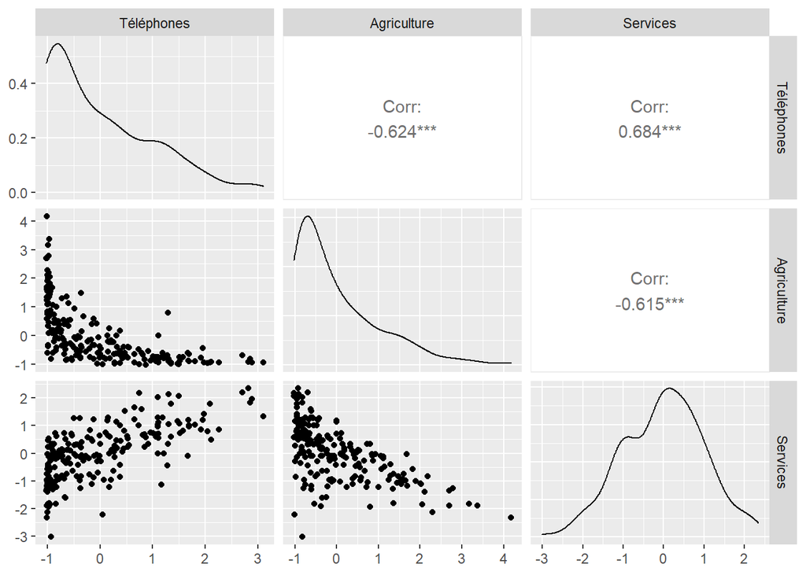

On a un facteur de corrélation d’environ 0.85 pour le couple de variables $T$ et PIB; on en déduit qu’elles sont fortement corrélées linéairement. Il en est de même pour les variables Services et $T$ avec un facteur de corrélation de 0.68. Finalement, la variable $T$ est également corrélée négativement à la variable Agriculture avec un coefficient de corrélation de -0,62 et à la variable Taux de natalité avec un coefficient de -0,73.

Nous avons maintenant une idée plus claire des liens entre notre variables d’intérêt et les variables quantitatives de notre jeu de données.

Nous allons terminer cette partie en nous intéressant à la variables Région, qui est une variable qualitative. Traçons le boxplot de la variable $T$ pour chaque modalité de la variable Région.

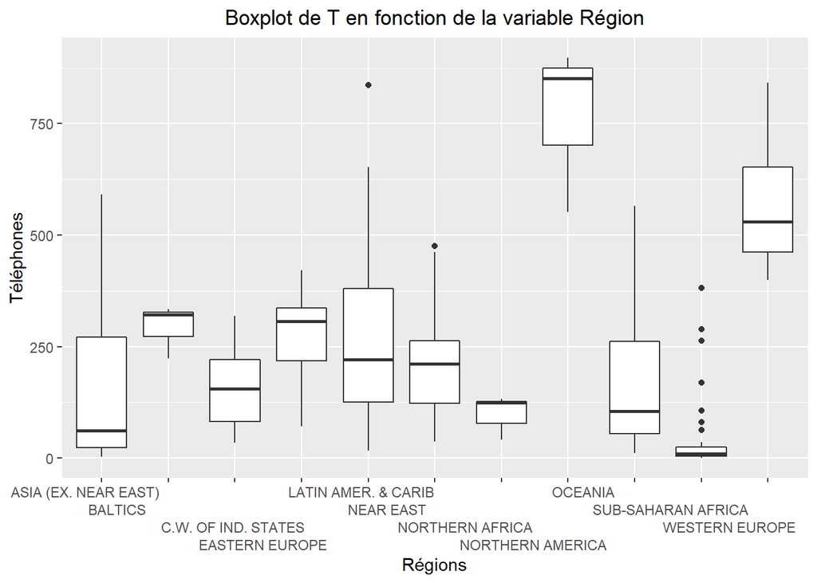

Les boxplots sont très différents, on peut penser que la région d’appartenance du pays joue un rôle important sur la variables $T$. On remarque qu’en Amérique du nord et en Europe de l’ouest, les médianes régionales sont hautes et qu’elles sont beaucoup plus basses en Afrique Sub-saharienne, en Océanie ou encore en Asie. Il y a parfois des observations hors-normes, notamment en Afrique sub-saharienne. Nous reviendrons, ci-besoin, sur ces observations plus loin dans notre rapport.

### II - Régression linéaire multiple

#### A - Modèle général

Dans cette partie, nous allons nous intéresser à une régression linéaire permettant d’exprimer la vraible $T$ par la densité de population (nombre d’habitants par miles carré), le PIB par habitant, le taux de natalité et enfin la part de la population active travaillant dans l’agriculture et les services.

On considère le modèle linéaire suivant:

Téléphones = $\beta_0$ + $\beta_1$Densité + $\beta_2$PIB + $\beta_3$ Agriculture + $\beta_4$Services + $\beta_5$Taux de natalité + $\varepsilon$

Nous avons déjà une première idée des corrélations linéaires de nos variables grace à la partie Analyse bi-variée. Nous allons ici formaliser ces relations et trouver les coefficients $\beta_j$. Dans le but de pouvoir comparer les $\beta_j$, nous devons centrer-réduire nos données et réaliser une régression sur ce nouveau jeu de données.

Réalisons une première régression linéaire.

```
Call:
lm(formula = Téléphones ~ Densité.population + PIB + Agriculture +
    Services + Taux.de.natalité, data = df.countries.scale)

Residuals:
    Min      1Q  Median      3Q     Max
-1.9452 -0.2198 -0.0401  0.2291  1.6664

Coefficients:
                     Estimate Std. Error t value Pr(>|t|)
(Intercept)         1.160e-16  2.985e-02   0.000    1.000
Densité.population -3.459e-02  3.092e-02  -1.119    0.265
PIB                 5.830e-01  4.197e-02  13.892  < 2e-16 ***
Agriculture         3.995e-02  4.506e-02   0.887    0.376
Services            2.626e-01  4.082e-02   6.431 8.96e-10 ***
Taux.de.natalité   -2.365e-01  4.536e-02  -5.213 4.58e-07 ***
---
Signif. codes:  0 '***' 0.001 '**' 0.01 '*' 0.05 '.' 0.1 ' ' 1

Residual standard error: 0.4305 on 202 degrees of freedom
Multiple R-squared:  0.8192,    Adjusted R-squared:  0.8147
F-statistic:   183 on 5 and 202 DF,  p-value: < 2.2e-16
```

Annalysons ce sommaire. Le $R^2$ vaut 0,8192 qui est proche de 1 avec une p-valeur associée très faible,donc on rejette l’hypothèse selon laquelle tous les $\beta_j$ sont nuls pour $j=0,...,5$. Le modèle de régression linéaire permet d’expliquer relativement bien notre variable $T$.

De plus, les tests de significativité des coefficients $\beta_2$, $\beta_4$ et $\beta_5$ donnent des p-valeurs inférieures à 0.001, donc $\beta_2$, $\beta_4$ et $\beta_5$ sont non nuls.

Nous allons vérifier que nos variables sont de “bonnes qualités” en cherchant si nous avons des valeurs aberrantes, des points leviers ou des distance de Cook trop élevées. Commençons par les valeurs aberrantes et les points levier.

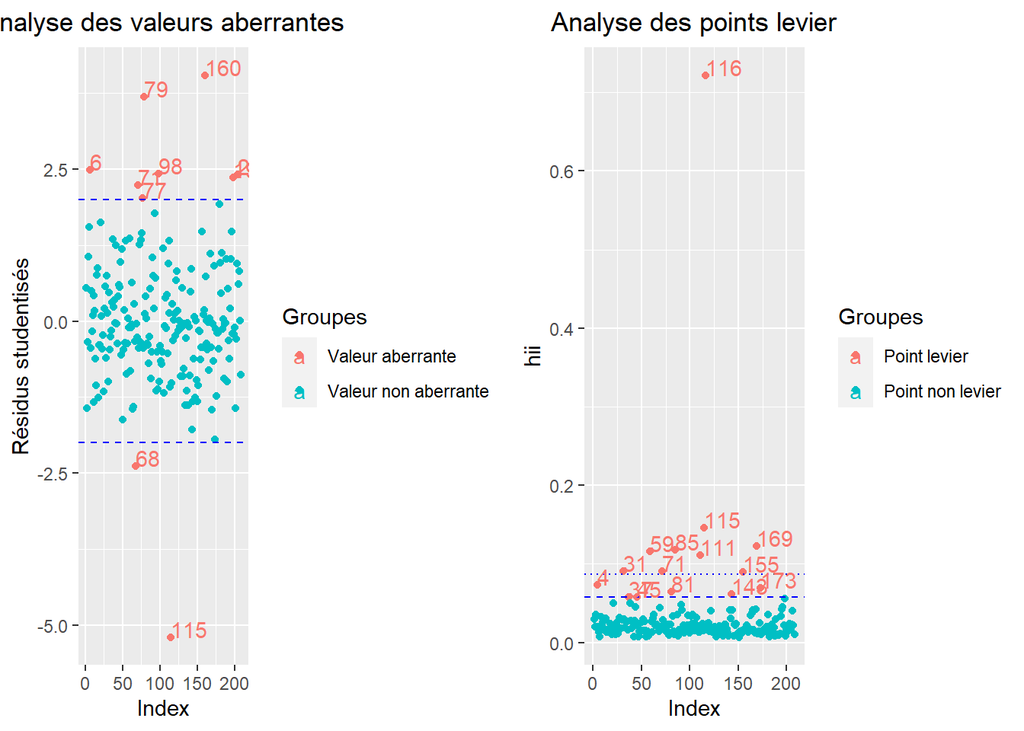

On a 10 valeurs aberrantes dans un échantillon de taille 208 donc 95% des résidus studentisés $t_i^*$ se trouvent dans l’intervalle [−2,2], soit une proportion acceptable. De plus, il y a 15 points leviers qui dépassent le deuxième seuil. Parmi les points leviers, l’observation 115, qui est le Luxembourg, est également une observation abérrante. Vérifions à présent les distances de Cook.

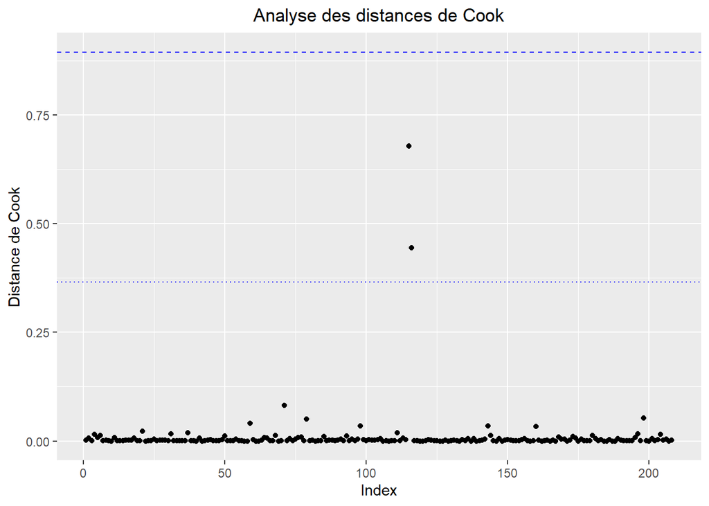

Aucune valeur n’a une distance de Cook supérieure au deuxième seuil, donc nous pouvons garder toutes nos observations.

Nos observations sont de “bonnes qualités”. Nous pouvons donc réaliser une sélection de variables.

#### B - Sélection de variables

Toutes nos variables sont potentiellement explicatives, trouvons celles qui interviennent réellement dans l’explication de $T$.

Commençons par regarder les facteurs d’inflation de la variance (VIF), pour vérifier si nos variables explicatives ne sont pas trop corrélées entre elles.

```
Densité.population                PIB        Agriculture           Services
          1.068183           1.967614           2.267844           1.861769
  Taux.de.natalité
          2.298902
```

Tout nos VIFS sont acceptables (inférieurs à 3).

Pour faire notre selection parmi les variables restantes,nous allons utiliser une procédure de modèle emboité. Comme notre modèle contient la constante, nous pouvons nous intéresser à la maximisation de $R^2_a$ et au critère BIC (Bayesian Information Criterion).

Commençons par un modèle avec nos 5 variables explicatives.

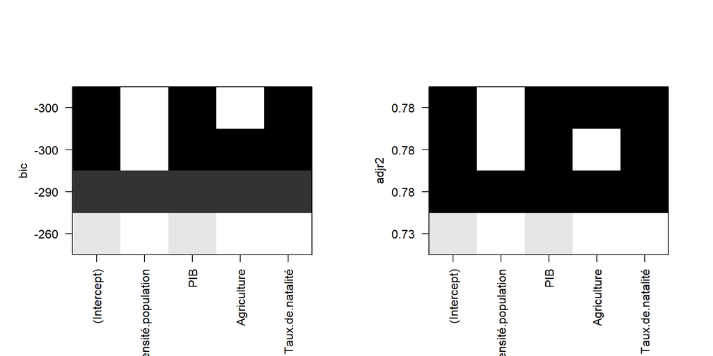

Nous supprimons les variables Densité et Agriculture.

On itère le procédé avec nos 3 variables explicatives restantes.

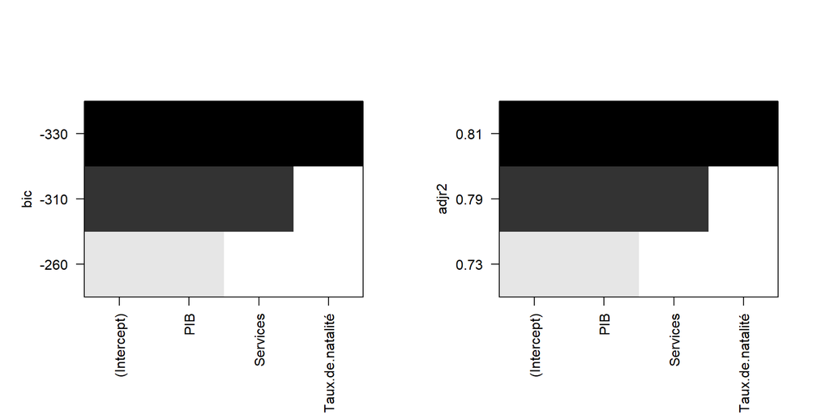

Nous gardons l’ensemble des variables restantes, c’est à dire le PIB, les Services et le Taux de natalité.

```
Call:
lm(formula = Téléphones ~ PIB + Services + Taux.de.natalité,
    data = df.countries.scale)

Residuals:
    Min      1Q  Median      3Q     Max
-1.8946 -0.2381 -0.0363  0.2340  1.6618

Coefficients:
                   Estimate Std. Error t value Pr(>|t|)
(Intercept)       9.902e-17  2.985e-02   0.000        1
PIB               5.753e-01  4.129e-02  13.932  < 2e-16 ***
Services          2.424e-01  3.783e-02   6.407 1.01e-09 ***
Taux.de.natalité -2.207e-01  4.144e-02  -5.326 2.64e-07 ***
---
Signif. codes:  0 '***' 0.001 '**' 0.01 '*' 0.05 '.' 0.1 ' ' 1

Residual standard error: 0.4305 on 204 degrees of freedom
Multiple R-squared:  0.8174,    Adjusted R-squared:  0.8147
F-statistic: 304.3 on 3 and 204 DF,  p-value: < 2.2e-16
```

Avec $\varepsilon$ une variable aléatoire inconnues.

#### C - Validation du modèle

Nous allons vérifier à nouveau que nous n’avons pas de valeurs problématiques en regardant les valeurs aberrantes, les points leviers et les distance de Cook.

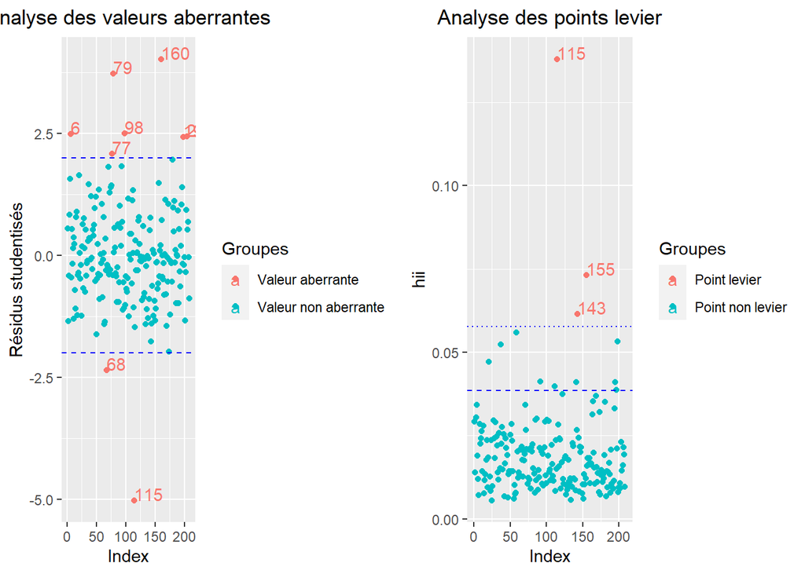

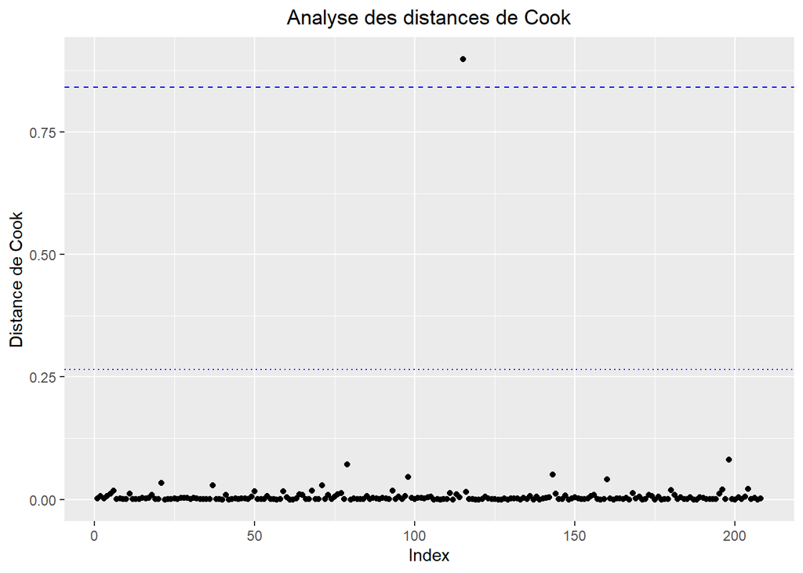

On a 9 valeurs aberrantes dans un échantillon de taille 208 donc 95% des résidus studientisés $t_i^*$ se trouvent dans l’intervalle [−2,2]. Il y a 3 points leviers qui dépassent le deuxième seuil. Parmi les points leviers, l’observation 115, qui est le Luxembourg, est également une observation abérrante. Nous avons une valeur qui a une distance de Cook qui dépasse le seuil préocuppant (0.84197) qui est également le 115. Nous décidons donc de supprimer cette observation et de réaliser une nouvelle régression linéaire.

```
Call:
lm(formula = Téléphones ~ PIB + Services + Taux.de.natalité,
    data = nouvcountries)

Residuals:
     Min       1Q   Median       3Q      Max
-1.04452 -0.21908 -0.02846  0.23302  1.67122

Coefficients:
                 Estimate Std. Error t value Pr(>|t|)
(Intercept)       0.01057    0.02830   0.373    0.709
PIB               0.64765    0.04163  15.557  < 2e-16 ***
Services          0.24171    0.03577   6.757 1.46e-10 ***
Taux.de.natalité -0.18391    0.03986  -4.613 7.01e-06 ***
---
Signif. codes:  0 '***' 0.001 '**' 0.01 '*' 0.05 '.' 0.1 ' ' 1

Residual standard error: 0.4071 on 203 degrees of freedom
Multiple R-squared:  0.836, Adjusted R-squared:  0.8336
F-statistic:   345 on 3 and 203 DF,  p-value: < 2.2e-16
```

Ainsi, après la sélection de variable et l’étude des observations, on en déduit que notre notre modèle linéaire s’écrit:

#### Téléphones = 0,65 PIB + 0,24 Services -0,18 Taux de natalité + $\varepsilon$

Nous avons centré et réduit nos observations donc nos coefficients $\beta_j$ sont comparables. dans un modèle linéaire, c’est le PIB du pays qui influence le plus $T$. la part de la population dans les serives inflence également positivement $T$, même si cette infleunce est moindre. Finalement, le taux de natalité du pays infleunce également $T$ mais cette fois-ci négativement.

Notons que les coefficients diffèrent des coefficients précemment trouvés lorqu’on avait gardé le Luxembourg.

À présent, nous allons réaliser une analyse de la normalité des résidus, pour vérifier si notre modèle linéaire est bien Gaussien. Traçons un QQ-plot qui compare les quantiles empiriques associés aux studendisés ($t_1^*,...,t_n^*$) aux quantiles de la loi de Student $\mathcal{T}(n-p-1)$ pour valider l’hypothèse que les résidus sont suivent une loi normale.

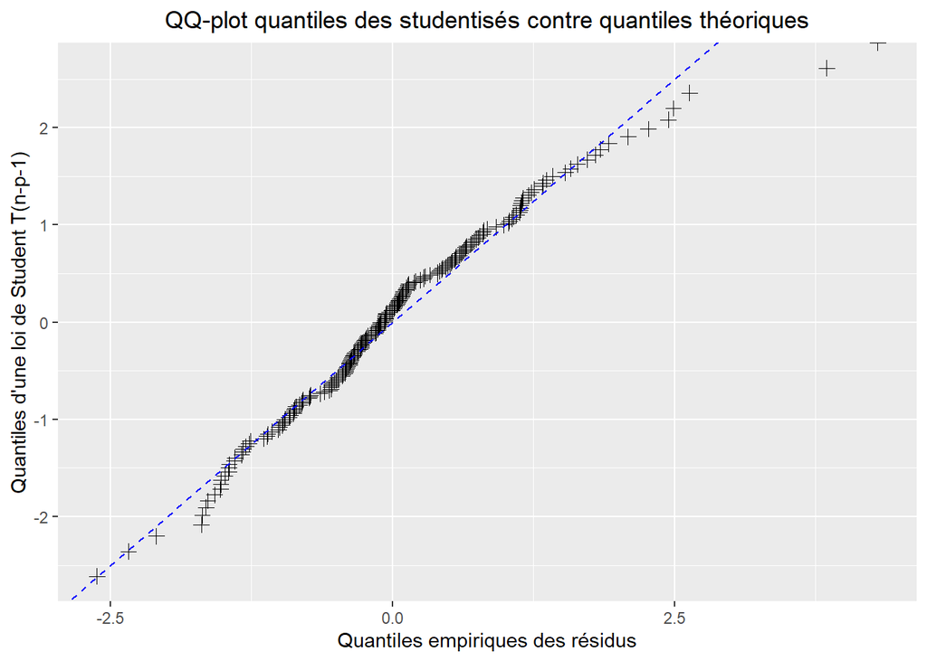

Le QQ-plot des résidus studendisées contre les quantiles d’une loi de Student de degrés de liberté n-p-1 =202 semble raisonnable. Nous pouvons donc valider l’hypothèse de la normalité des résidus. Notre modèle linéaire est donc Gaussien.

## III - Modélisation linéaire avec variable qualitative, réalisation d’une ANOVA.

### A- Apprentissage du modèle

La parti précedente nous a conforté dans l’idée qu’un modèle linéaire explique relativement bien $T$. Nous souhaitons donc ajouter une nouvelle variable, cette fois-ci qualitative, potentiellement explicative de $T$:la Région d’appartenance du pays.Nous gardons donc nos trois variables quantitatives précédentes (pour se limiter à une étude de taille acceptable) soit le PIB, le taux de natalité et la proportion de la population dans les services et nous ajoutons la variable région.

```
Call:
lm(formula = Téléphones ~ Région * Services * Taux.de.natalité *
    PIB, data = df.countries.scale.app)

Residuals:
     Min       1Q   Median       3Q      Max
-0.90893 -0.12102 -0.00338  0.06777  1.44344

Coefficients: (15 not defined because of singularities)
                                                                          Estimate
(Intercept)                                                              8.608e-02
RégionBALTICS                                                            7.852e-01
RégionC.W. OF IND. STATES                                               -9.340e-01
RégionEASTERN EUROPE                                                    -6.559e+00
RégionLATIN AMER. & CARIB                                                2.169e-01
RégionNEAR EAST                                                         -1.278e+00
RégionNORTHERN AFRICA                                                   -6.192e-01
RégionNORTHERN AMERICA                                                  -1.869e+00
RégionOCEANIA                                                           -1.062e+00
RégionSUB-SAHARAN AFRICA                                                -7.401e-01
RégionWESTERN EUROPE                                                     8.634e+00
Services                                                                 3.982e-01
Taux.de.natalité                                                         1.972e-01
PIB                                                                      1.206e+00
RégionBALTICS                            :Services                       9.262e-01
RégionC.W. OF IND. STATES :Services                                     -1.637e+00
RégionEASTERN EUROPE                     :Services                      -1.408e+01
RégionLATIN AMER. & CARIB    :Services                                  -2.606e-01
RégionNEAR EAST                          :Services                       7.955e-02
RégionNORTHERN AFRICA                    :Services                      -4.904e-01
RégionNORTHERN AMERICA                   :Services                      -1.710e-01
RégionOCEANIA                            :Services                       3.341e-01
RégionSUB-SAHARAN AFRICA                 :Services                      -2.764e-01
RégionWESTERN EUROPE                     :Services                      -7.917e+00
RégionBALTICS                            :Taux.de.natalité               8.865e-01
RégionC.W. OF IND. STATES :Taux.de.natalité                             -1.370e+00
RégionEASTERN EUROPE                     :Taux.de.natalité              -5.931e+00
RégionLATIN AMER. & CARIB    :Taux.de.natalité                          -1.598e-01
RégionNEAR EAST                          :Taux.de.natalité              -2.223e+00
RégionNORTHERN AFRICA                    :Taux.de.natalité               7.108e-01
```

[output cut: 405 more lines]

```
RégionC.W. OF IND. STATES :Services:Taux.de.natalité:PIB
RégionEASTERN EUROPE                     :Services:Taux.de.natalité:PIB
RégionLATIN AMER. & CARIB    :Services:Taux.de.natalité:PIB
RégionNEAR EAST                          :Services:Taux.de.natalité:PIB
RégionNORTHERN AFRICA                    :Services:Taux.de.natalité:PIB
RégionNORTHERN AMERICA                   :Services:Taux.de.natalité:PIB
RégionOCEANIA                            :Services:Taux.de.natalité:PIB
RégionSUB-SAHARAN AFRICA                 :Services:Taux.de.natalité:PIB
RégionWESTERN EUROPE                     :Services:Taux.de.natalité:PIB
---
Signif. codes:  0 '***' 0.001 '**' 0.01 '*' 0.05 '.' 0.1 ' ' 1

Residual standard error: 0.3836 on 93 degrees of freedom
Multiple R-squared:  0.9228,    Adjusted R-squared:  0.863
F-statistic: 15.44 on 72 and 93 DF,  p-value: < 2.2e-16
```

Nous allons maintenant réaliser une sélection de variables.

```
Analysis of Variance Table

Response: Téléphones
                                     Df  Sum Sq Mean Sq  F value    Pr(>F)
Région                               10 100.744 10.0744  68.4523 < 2.2e-16 ***
Services                              1  24.324 24.3243 165.2749 < 2.2e-16 ***
Taux.de.natalité                      1  12.428 12.4285  84.4469 1.061e-14 ***
PIB                                   1  10.749 10.7486  73.0331 2.425e-13 ***
Région:Services                      10   3.668  0.3668   2.4925 0.0107327 *
Région:Taux.de.natalité              10   2.034  0.2034   1.3824 0.2006110
Services:Taux.de.natalité             1   1.600  1.5996  10.8687 0.0013858 **
Région:PIB                            7   4.271  0.6102   4.1461 0.0005209 ***
Services:PIB                          1   0.262  0.2622   1.7818 0.1851921
Taux.de.natalité:PIB                  1   0.002  0.0017   0.0117 0.9141573
Région:Services:Taux.de.natalité      7   1.334  0.1905   1.2946 0.2616538
Région:Services:PIB                   7   0.585  0.0835   0.5674 0.7806240
Région:Taux.de.natalité:PIB           7   0.850  0.1214   0.8250 0.5690850
Services:Taux.de.natalité:PIB         1   0.100  0.1000   0.6793 0.4119390
Région:Services:Taux.de.natalité:PIB  7   0.608  0.0868   0.5898 0.7626704
Residuals                            93  13.687  0.1472
---
Signif. codes:  0 '***' 0.001 '**' 0.01 '*' 0.05 '.' 0.1 ' ' 1
```

De nombreuses interactions entre nos variables ne semblent pas avoir d’effet significatif sur $T$, nous les supprimont.

```
Analysis of Variance Table

Response: Téléphones
                           Df  Sum Sq Mean Sq  F value    Pr(>F)
Région                     10 100.744 10.0744  71.1878 < 2.2e-16 ***
Services                    1  24.324 24.3243 171.8796 < 2.2e-16 ***
Taux.de.natalité            1  12.428 12.4285  87.8216 4.466e-16 ***
PIB                         1  10.749 10.7486  75.9516 1.644e-14 ***
Région:PIB                 10   7.516  0.7516   5.3110 1.745e-06 ***
Services:Taux.de.natalité   1   1.751  1.7505  12.3696  0.000612 ***
Région:Services            10   1.503  0.1503   1.0618  0.396915
Taux.de.natalité:PIB        1   0.095  0.0952   0.6728  0.413666
Région:Taux.de.natalité     7   0.729  0.1042   0.7364  0.641522
Residuals                 123  17.407  0.1415
---
Signif. codes:  0 '***' 0.001 '**' 0.01 '*' 0.05 '.' 0.1 ' ' 1
```

Idem, nous enlevons les 3 interactions non significatives.

```
Analysis of Variance Table

Response: Téléphones
                           Df  Sum Sq Mean Sq  F value    Pr(>F)
Région                     10 100.744 10.0744  71.9817 < 2.2e-16 ***
Services                    1  24.324 24.3243 173.7964 < 2.2e-16 ***
Taux.de.natalité            1  12.428 12.4285  88.8010 < 2.2e-16 ***
PIB                         1  10.749 10.7486  76.7986 5.427e-15 ***
Région:PIB                 10   7.516  0.7516   5.3703 1.048e-06 ***
Services:Taux.de.natalité   1   1.751  1.7505  12.5076  0.000549 ***
Residuals                 141  19.734  0.1400
---
Signif. codes:  0 '***' 0.001 '**' 0.01 '*' 0.05 '.' 0.1 ' ' 1
```

Toutes les variables et interactions restantes sont significatives. La probabilité critique associée à la variable région est inférieure à 0.1%. On rejette donc l’hypothèse que la région d’appartenance du pays n’a pas d’effet sur $T$. On retient que les variables PIB, Services et Taux de natalité ont encore un effet sur $T$. De plus, nous apprenons ici qu’il y a un effet d’interaction entre la Région et le PIB ainsi qu’entre Services et Taux de natalité.

Finissons par réaliser une analyse des résidus.

Commençons par regarder si nous avons des valeurs aberrantes et des points leviers.

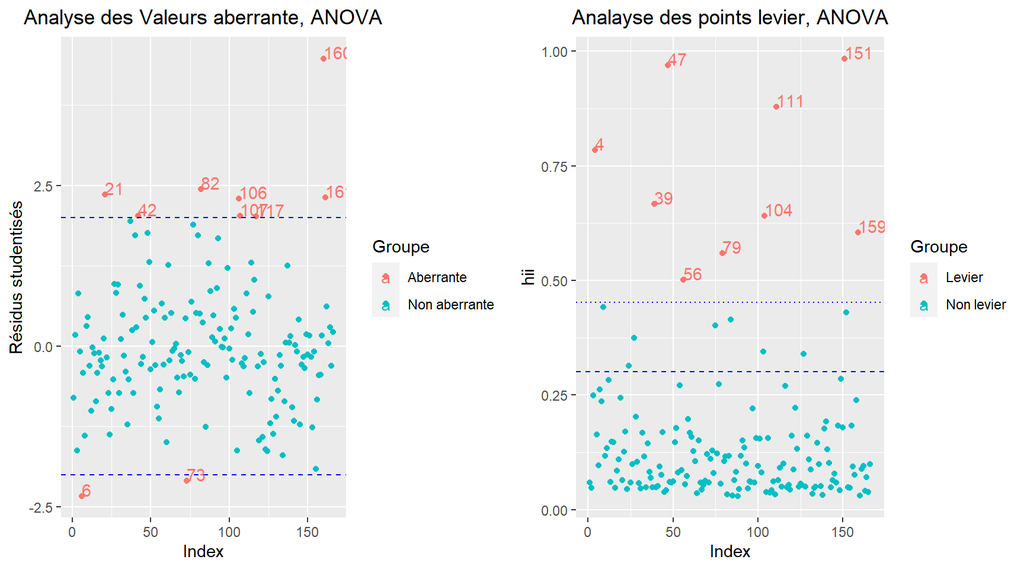

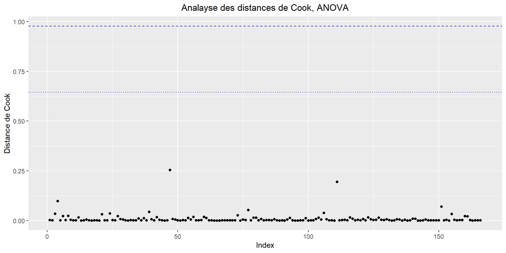

Aucune distance de Cook ne dépasse le premier seuil et à fortiori le deuxième. Nous pouvons donc garder toutes nos observations.

Finalisons cette analyse en vérifiant l’hypothèse de normalité des résidus.

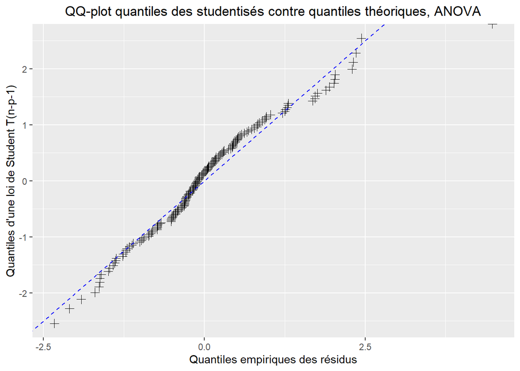

On peut valider l’hypothèse selon laquelle les résidus sont gaussiens. Pour conclure, on accepte notre modèlisation du problème